# Parametric Survival models for cTTO data

## Spanish Valuation Data

First we set up the data, including stratification (code hidden for readability).

We first set up some internal functions that will do all the fitting for us (code hidden for readability)

We use the standard 20-dummy + intercept main effects model, using leave-a-state-out cross-validation to assess model fit.

Now we can look at the fit of the models. To begin, we compare the out-of-sample predicted survival curves for a random sample of 10 health states to the Kaplan-Meier survival curve.

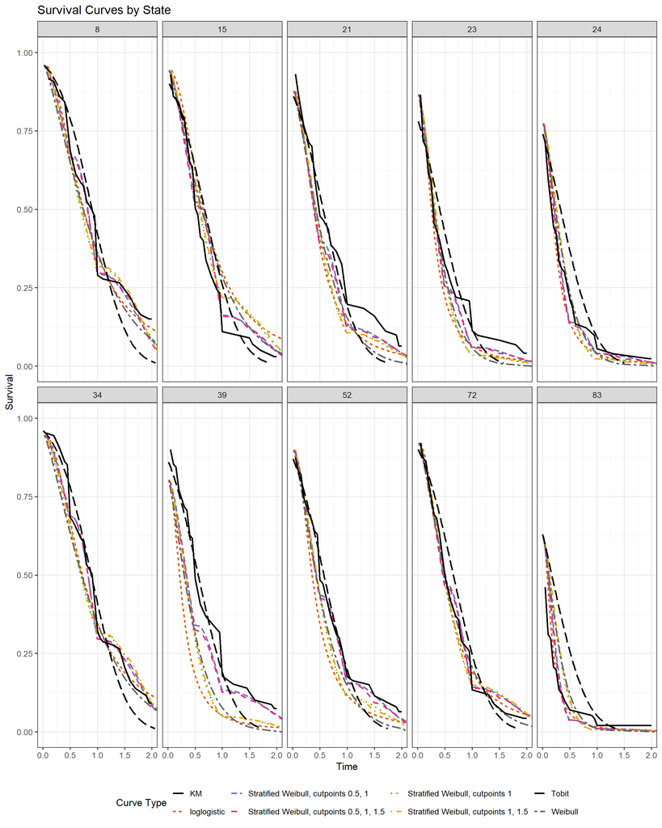

```r
subset <- sample(1:86, 10, replace=FALSE)

all_df2subset <- all_df2 %>% filter(state_id %in% subset)

ggplot(all_df2subset, aes(x = time, y = surv, color = type, linetype=type)) +
  geom_line(aes(color=type,linetype=type),size=0.9,alpha=1) +
  geom_line(data=subset(all_df2subset,type=="KM"),size=1, color="black") +
    geom_line(data=subset(all_df2subset,type=="Tobit"),size=1, color="black") +
  scale_y_continuous(limits = c(0, 1)) +
 coord_cartesian(xlim = c(0, 2)) +
  facet_wrap(~ state_id, ncol = 5) +
  # theme_minimal(base_size = 14) +
#  scale_color_manual(values = c("KM" = "black", "Stratified Weibull" = "green", "Tobit"="red")) +
  labs(
    title = "Survival Curves by State",
    x = "Time",
    y = "Survival",
    color = "Curve Type",
    linetype="Curve Type"
  ) +
  scale_color_brewer(palette = "Dark2") +
  theme_bw(base_size = 13) +
  theme(legend.position="bottom")
```

Next, we look at the out-of-sample predicted restricted mean survival times, with survival times up to 1, 1.5 and 2. For each model we first plot the predicted restricted mean survival times for the 86 health states vs. the Kaplan-Meier restricted means, the plot the difference between the model-predicted restricted mean survival time and the Kaplan-Meier survival time vs. the Kaplan-Meier survival time (i.e., a Bland-Altman plot). Trends in the plot are modelled via a generalized additive model, and limits of agreement computed using the standard deviation of the points from the fitted mean curve.

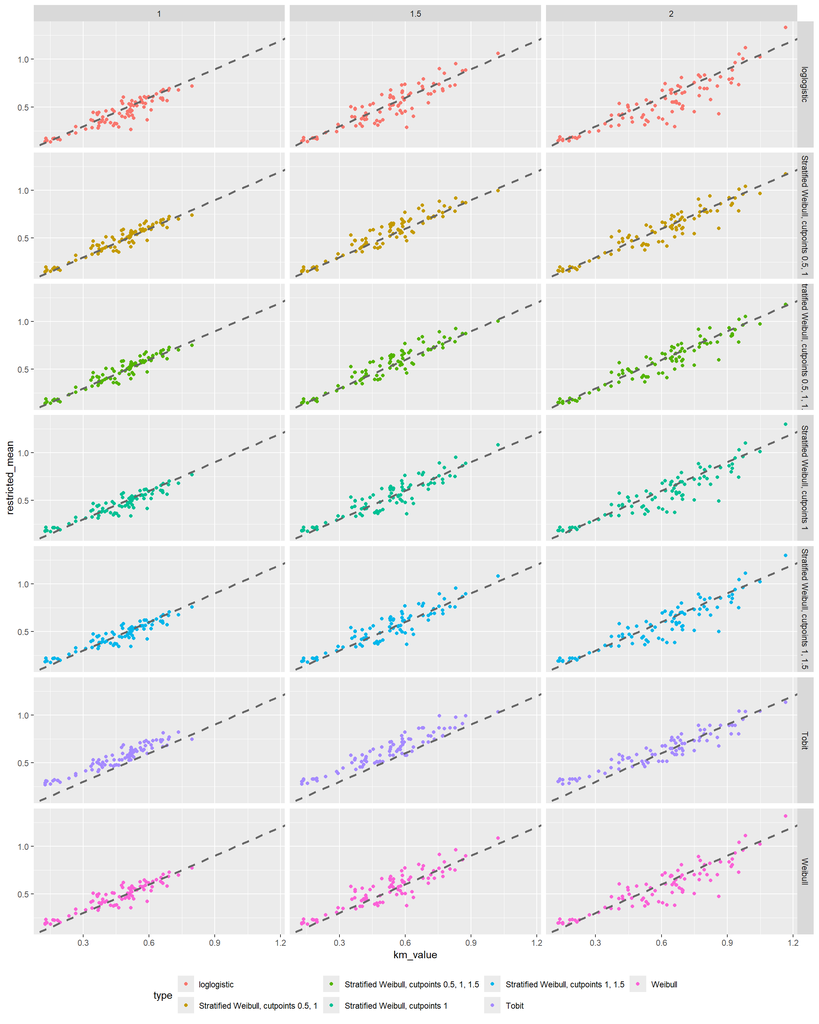

```r
ggplot(data=rest_means$RestMean_Diff, aes(y=restricted_mean, x=km_value, color=type)) +
 geom_point() +
  facet_grid( type~ tau) +
  geom_abline(intercept = 0,
    slope = 1,
    linetype = "dashed",
    color = "grey40",
    linewidth = 1
  )+
  theme(legend.position="bottom")
```

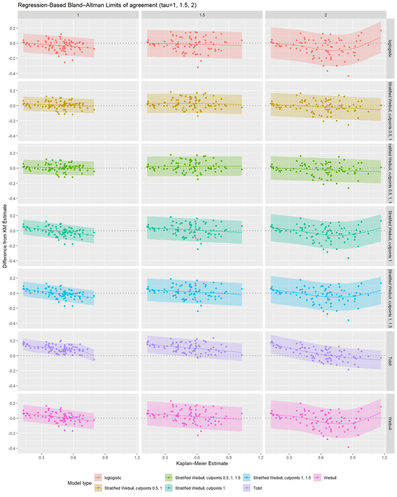

```r
Bias_by_TypeandTau <- rest_means$RestMean_Diff %>% group_by(type,tau)%>% summarise(bias = mean(diff_from_KM), sd=sd(diff_from_KM), mae=mean(abs(diff_from_KM)),sd_BA=sd(diff_from_KM - gamfit), .groups="drop")

RestMean_Diff <-
  rest_means$RestMean_Diff %>% left_join(Bias_by_TypeandTau,by=c("type","tau"))
RestMean_Diff <- RestMean_Diff %>% mutate(loa_lower = gamfit - 1.96*sd_BA, loa_upper = gamfit + 1.96*sd_BA)
RestMean_Diff <- RestMean_Diff %>%
  arrange(type, tau, km_value)

ggplot(data=RestMean_Diff,aes(x=km_value,y=diff_from_KM,color=type,fill=type)) +
    geom_point() +
    geom_line(aes(y=gamfit)) +
    facet_grid(type~tau) +
    geom_hline(yintercept = 0, linetype = "dashed", color = "grey50")+
    geom_ribbon(aes(ymin=loa_lower, ymax=loa_upper,fill=type,group=interaction(type,tau)),alpha=0.25, color=NA) +
    labs(
        title = "Regression-Based Bland–Altman Limits of agreement (tau=1, 1.5, 2)",
        x = "Kaplan–Meier Estimate",
        y = "Difference from KM Estimate",
        color = "Model type",
        fill  = "Model type"
    )+
  theme(legend.position="bottom")
```

Summary statistics for the predicted restricted mean survival times (vs. the Kaplan-Meier restricted means) appear below. Ideally we want small absolute bias and the standard deviation of the Bland-Altman limits of agreement (sd_BA) to be as small as possible.

```r
Bias_by_TypeandTau %>% filter(tau==1) %>% kable(digits=3)
```

| type | tau | bias | sd | mae | sd_BA |
| --- | --- | --- | --- | --- | --- |
| Stratified Weibull, cutpoints 0.5, 1 | 1 | 0.010 | 0.048 | 0.037 | 0.048 |
| Stratified Weibull, cutpoints 0.5, 1, 1.5 | 1 | 0.007 | 0.049 | 0.037 | 0.049 |
| Stratified Weibull, cutpoints 1 | 1 | -0.007 | 0.058 | 0.045 | 0.051 |
| Stratified Weibull, cutpoints 1, 1.5 | 1 | -0.002 | 0.058 | 0.045 | 0.050 |
| Tobit | 1 | 0.093 | 0.050 | 0.094 | 0.041 |
| Weibull | 1 | 0.015 | 0.062 | 0.050 | 0.056 |
| loglogistic | 1 | -0.030 | 0.066 | 0.053 | 0.064 |

```r
Bias_by_TypeandTau %>% filter(tau==1.5) %>% kable(digits=3)
```

| type | tau | bias | sd | mae | sd_BA |
| --- | --- | --- | --- | --- | --- |
| Stratified Weibull, cutpoints 0.5, 1 | 1.5 | 0.029 | 0.066 | 0.054 | 0.065 |
| Stratified Weibull, cutpoints 0.5, 1, 1.5 | 1.5 | 0.025 | 0.067 | 0.054 | 0.067 |
| Stratified Weibull, cutpoints 1 | 1.5 | 0.013 | 0.079 | 0.063 | 0.078 |
| Stratified Weibull, cutpoints 1, 1.5 | 1.5 | 0.019 | 0.079 | 0.065 | 0.077 |
| Tobit | 1.5 | 0.106 | 0.064 | 0.107 | 0.059 |
| Weibull | 1.5 | 0.029 | 0.084 | 0.072 | 0.082 |
| loglogistic | 1.5 | -0.013 | 0.092 | 0.071 | 0.091 |

```r
Bias_by_TypeandTau %>% filter(tau==2) %>% kable(digits=3)
```

| type | tau | bias | sd | mae | sd_BA |
| --- | --- | --- | --- | --- | --- |
| Stratified Weibull, cutpoints 0.5, 1 | 2 | -0.014 | 0.080 | 0.061 | 0.078 |
| Stratified Weibull, cutpoints 0.5, 1, 1.5 | 2 | -0.020 | 0.080 | 0.062 | 0.079 |
| Stratified Weibull, cutpoints 1 | 2 | -0.030 | 0.100 | 0.078 | 0.092 |
| Stratified Weibull, cutpoints 1, 1.5 | 2 | -0.023 | 0.100 | 0.076 | 0.093 |
| Tobit | 2 | 0.030 | 0.086 | 0.075 | 0.064 |
| Weibull | 2 | -0.029 | 0.107 | 0.084 | 0.095 |
| loglogistic | 2 | -0.059 | 0.115 | 0.095 | 0.106 |

Next we compare predicted medians under cross-validition to Kaplan-Meier medians

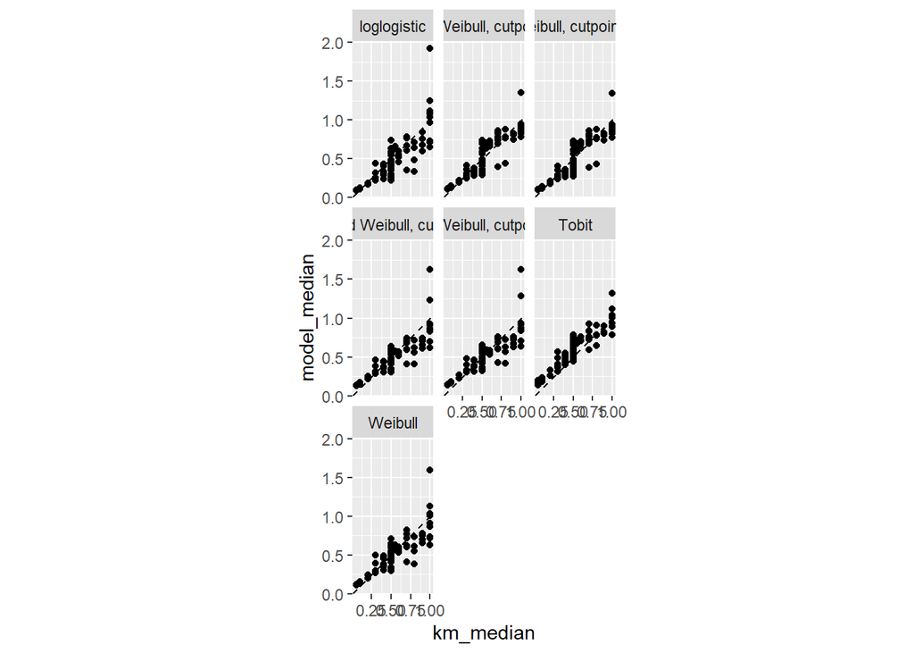

```r
# find medians
medians_df <- all_df2 %>% arrange(type,state_id,time) %>% group_by(type,state_id) %>%
  filter(surv<=0.5) %>% slice(1) %>%
  ungroup()

km_medians <- medians_df %>% filter(type=="KM") %>% mutate(km_median=time) %>% select(state_id,km_median) %>% arrange(state_id)

medians_df <- medians_df %>% filter(type!="KM") %>% left_join(km_medians,by="state_id") %>% mutate(model_median=time, diff_from_km = model_median-km_median)

ggplot(medians_df,aes(x=km_median,y=model_median)) + geom_point() + facet_wrap(~type) + geom_abline(slope=1,intercept=0,linetype="dashed") + coord_equal()
```

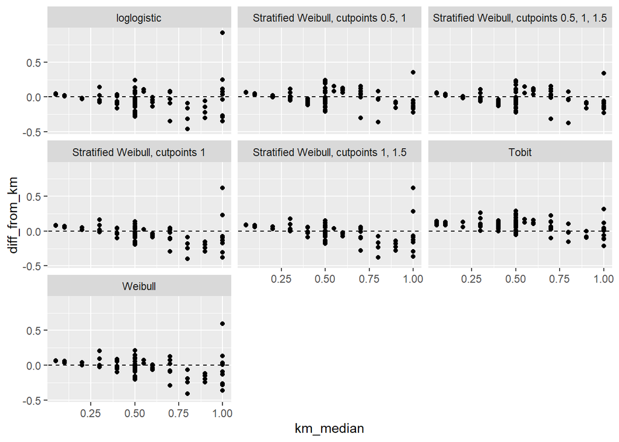

```r
ggplot(medians_df,aes(x=km_median,y=diff_from_km)) + geom_point() + facet_wrap(~type) + geom_abline(slope=0,intercept=0,linetype="dashed")
```

```r
Median_Diagnostics <- medians_df %>%
  group_by(type) %>% mutate(diff = (model_median-km_median)) %>%
summarise(MAE=mean(abs(diff)), RMSE=sqrt(mean(diff^2)), bias=mean(diff))

Median_Diagnostics %>% kable(digits=3)
```

| type | MAE | RMSE | bias |
| --- | --- | --- | --- |
| Stratified Weibull, cutpoints 0.5, 1 | 0.091 | 0.117 | -0.013 |
| Stratified Weibull, cutpoints 0.5, 1, 1.5 | 0.092 | 0.118 | -0.024 |
| Stratified Weibull, cutpoints 1 | 0.103 | 0.145 | -0.040 |
| Stratified Weibull, cutpoints 1, 1.5 | 0.099 | 0.142 | -0.026 |
| Tobit | 0.105 | 0.123 | 0.078 |
| Weibull | 0.098 | 0.140 | -0.026 |
| loglogistic | 0.117 | 0.173 | -0.045 |

Lastly, compare models on the full dataset

```r
models_fitted <- fitmodels(data,datasplit2,datasplit,datasplit3,datasplit4,omit.state=100,func.form=~mo + sc + ua + pd + ad,printfit=TRUE)
```

```
             df       BIC
mtobit       22 15523.287
mloglogistic 22  8979.629
mweibull     22  9568.220
mweibulli    44  8294.894
mweibullii   66  8419.366
mweibulliii  88  6563.557
mweibulliv   66  6510.930
```

The coefficients for the non-stratified models

```r
models_fitted$model_table %>%
  kbl(caption = "Fitted Weibull, Log-logistic, and Tobit models", digits=2) %>%
  kable_classic(full_width = FALSE, font = "Arial")
```

Fitted Weibull, Log-logistic, and Tobit models

| term | Weibull AFT/PH_estimate | Weibull AFT/PH_std.error | Weibull AFT/PH_p.value | Log-logistic AFT_estimate | Log-logistic AFT_std.error | Log-logistic AFT_p.value | Tobit AFT_estimate | Tobit AFT_std.error | Tobit AFT_p.value |
| --- | --- | --- | --- | --- | --- | --- | --- | --- | --- |
| (Intercept) | -1.24 | 0.03 | 0.00 | -2.00 | 0.04 | 0.00 | 0.12 | 0.02 | 0.00 |
| mo2 | 0.02 | 0.03 | 0.43 | 0.09 | 0.03 | 0.01 | 0.01 | 0.02 | 0.57 |
| mo3 | 0.17 | 0.03 | 0.00 | 0.25 | 0.03 | 0.00 | 0.06 | 0.02 | 0.00 |
| mo4 | 0.35 | 0.03 | 0.00 | 0.48 | 0.04 | 0.00 | 0.21 | 0.02 | 0.00 |
| mo5 | 0.33 | 0.03 | 0.00 | 0.48 | 0.03 | 0.00 | 0.24 | 0.02 | 0.00 |
| sc2 | 0.10 | 0.03 | 0.00 | 0.15 | 0.03 | 0.00 | 0.04 | 0.02 | 0.04 |
| sc3 | 0.13 | 0.03 | 0.00 | 0.20 | 0.04 | 0.00 | 0.03 | 0.02 | 0.09 |
| sc4 | 0.27 | 0.03 | 0.00 | 0.36 | 0.03 | 0.00 | 0.16 | 0.02 | 0.00 |
| sc5 | 0.26 | 0.03 | 0.00 | 0.33 | 0.03 | 0.00 | 0.18 | 0.02 | 0.00 |
| ua2 | 0.08 | 0.03 | 0.01 | 0.10 | 0.03 | 0.00 | 0.04 | 0.02 | 0.04 |
| ua3 | 0.17 | 0.03 | 0.00 | 0.22 | 0.03 | 0.00 | 0.07 | 0.02 | 0.00 |
| ua4 | 0.28 | 0.03 | 0.00 | 0.39 | 0.03 | 0.00 | 0.16 | 0.02 | 0.00 |
| ua5 | 0.16 | 0.03 | 0.00 | 0.25 | 0.03 | 0.00 | 0.13 | 0.02 | 0.00 |
| pd2 | 0.11 | 0.03 | 0.00 | 0.18 | 0.03 | 0.00 | 0.05 | 0.02 | 0.00 |
| pd3 | 0.23 | 0.03 | 0.00 | 0.30 | 0.04 | 0.00 | 0.10 | 0.02 | 0.00 |
| pd4 | 0.28 | 0.03 | 0.00 | 0.41 | 0.03 | 0.00 | 0.19 | 0.02 | 0.00 |
| pd5 | 0.45 | 0.03 | 0.00 | 0.56 | 0.03 | 0.00 | 0.28 | 0.02 | 0.00 |
| ad2 | 0.13 | 0.03 | 0.00 | 0.21 | 0.04 | 0.00 | 0.06 | 0.02 | 0.00 |
| ad3 | 0.19 | 0.03 | 0.00 | 0.35 | 0.04 | 0.00 | 0.10 | 0.02 | 0.00 |
| ad4 | 0.39 | 0.03 | 0.00 | 0.55 | 0.03 | 0.00 | 0.21 | 0.02 | 0.00 |
| ad5 | 0.44 | 0.03 | 0.00 | 0.58 | 0.03 | 0.00 | 0.26 | 0.02 | 0.00 |
| Log(scale) | -0.27 | 0.01 | 0.00 | -0.72 | 0.01 | 0.00 | -0.69 | 0.01 | 0.00 |

Outstanding issues: the above analyses treat cTTO values from the same individual as independent, i.e., ignore heterogeneity. Furthermore, it treats the probability of any trading as independent of the survival distribution conditional on trading, which is likely not the case. This will lead to bias, as the link functions are not linear. The next step is to fit the logistic model for any trading and the stratified Weibull models using a common (or at least correlated) frailty parameter (i.e., random effect).